# STA304

2016-01-28

## proportions (and counts)

## categorical data

A significant amount of sample data is categorical in nature, as opposed to fundamentally numerical. But the line can be blurry.

- "Failed" vs. "Not Failed"
- "Liberal", "Conservative", "NDP", "Green", "BQ"
- Gas pipes come in 1.0, 1.5, and 1.75 inch sizes
- Likert scale questions (thousands of papers arguing about these!)

In this course we'll only consider the case of two outcomes, which is not as limiting as it sounds.

LifeProTip: use *proportions* and not *percentages*—the latter are merely formatting conventions for human viewing.

## analogy/notation

Recall the actual population:\[{\{e_1, e_2, \ldots, e_N\}}\]which we have usually conflated with (numerical) *measurements taken* on thepopulation:\[{\{y_1, y_2, \ldots, y_N\}}\]

For the case of proportions and counts, we can simply (arbitrarily) code the two outcomes as 0 and 1 and then use all the previous theory.

But just to mess with you we'll change the notation. Rather than \(\mu\) (the population mean) we'll use \(p\) (the population proportion of 1s) although the definition is identical: \(p = \frac{1}{N}\sum_{i=1}^N y_i\). For convenience we'll also define \(q = 1 - p\) (the population proportion of 0s)

## the population variance (not in book!)

The population variance is *defined* (like before) as: \(\sigma^2 = \frac{1}{N}\sum_{i=1}^N \left(y_i - p\right)^2\). This turns out to be:

\[\begin{align*} \sigma^2=\frac{1}{N}\sum_{i=1}^N \left(y_i - p\right)^2 &= \frac{1}{N}\left(\sum_{i=1}^N y_i^2 - Np^2\right)\\ &= \frac{1}{N}\left(\sum_{i=1}^N y_i - Np^2\right)\\ &= \frac{1}{N}\left(Np - Np^2\right)\\ &= p(1-p) = pq \end{align*}\]

## the sample and its properties

So we don't know what \(p\) is. We plan to gather a sample \({\{y_1, y_2, \ldots, y_n\}}\). Under simple random sample this sample has some familiar properties.

- The \(y_i\) have the same distribution with pmf as follows\[\begin{equation*} y_i = \begin{cases} 1 & \text{with probability } p,\\ 0 & \text{with probability } 1-p = q \end{cases} \end{equation*}\]*(stats people would prefer the more useful: \(p(y) = p^y(1-p)^{1-y}\) for \(y\in\{0,1\}\))*
- \({E{\left(y_i\right)}} = p\) and \(V(y_i) = pq\)
- But the \(y_i\) are *not* independent…
- We won't use this, but what is the *distribution* of \(k\), the number of 1s (some may know)?

## estimating \(p\) under SRS

Use the usual estimator with a new name:\[{\overline{y}} = \hat{p} = \frac{1}{n}\sum_{i=1}^n y_i\]

If I need to I might also declare \(k\) to be the "number of 1s" in the sample and use \(\hat{p} = k/n\).

For convenience we'll also define \(\hat{q} = 1 - \hat{p}\).

\(\hat{p}\) is unbiased for \(p\) (easy exercise)

## the true variance of \(\hat{p}\)

Since there's nothing special about 0s and 1s for population values we can recycle the old methods:\[\begin{align*} V(\hat{p}) &= \frac{\sigma^2}{n}\left(\frac{N-n}{N-1}\right) \text{ (copied from before)}\\ &= \frac{pq}{n}\left(\frac{N-n}{N-1}\right) \text{ (since $\sigma^2 = pq$)} \end{align*}\]

And, \(s^2 = \frac{1}{n-1}\sum_{i=1}^n \left(y_i - \hat{p}\right)^2\) is still used to estimate \(\sigma^2 = pq\). It turns out that \(s^2 = \frac{n\hat{p}\hat{q}}{n-1}\), so we end up with this unbiased estimator for \(V(\hat{p})\):\[\hat{V}(\hat{p}) = \frac{\hat{p}\hat{q}}{n-1}\frac{N-n}{N}\]Due to symmetry \(\hat{V}(\hat{q}) = \hat{V}(\hat{p})\).

## (counts)

Population total remains: \(\tau = \sum_{i=1}^N y_i\). No special notation this time.

Results: use \(Np=\tau\), so essentially multiply by \(N\) as appropriate.

## example

A gas distribution company has employees and contractors who install and repair equipment. It is important that the work be performed up to standard. The company has a Quality Assurance (QA) program that audits samples of work done. The QA program selects a SRS of \(n=412\) out of \(N=12251\) tasks to audit. A task "conforms" if it meets all "technical" *and* "paperwork" standards.

In the SRS \(k = 377\) tasks were found to conform. Estimate the proportion of conforming tasks. Estimate the number of non-conforming tasks that will require follow-up work.

We have \(\hat{p} = 0.915\) with standard error \({\sqrt{\hat{V}(\hat{p})}} = \sqrt{\frac{\hat{p}\hat{q}}{n-1}\frac{N-n}{N}} = 0.014\) and a 95% C.I. is \([0.888, 0.942]\).

A 95% C.I. for the number of non-conforming tasks (simply \(Nq\), estimated by \(N\hat{q}\)) is then \([709.487, 1371.993]\).

## sample size selection for proportions

For a bound \(B\) on estimation error and assuming 95% confidence level, the recycled formula becomes:\[n = \frac{N\sigma^2}{(N-1)B^2/4 + \sigma^2} = \frac{Npq}{(N-1)B^2/4 + pq}\]along with the classic "but we don't know" (…in this case…) "\(p\)" problem.

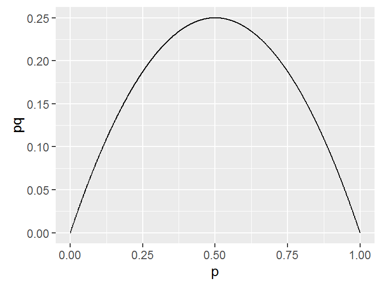

How to handle this problem requires an understanding of \(pq=p(1-p)\) as a function of \(p\).

Maximum at \(p=0.5\) and symmetric.

## handling the unknown \(p\) problem

The basic rule is: use as a "guess" the closest value to 0.5 that prior knowledge gives you. Examples:

- You have good information that the true value is between 0.2 and 0.3. **Use 0.3 in the sample size formula**.
- You have good information that the true value is between 0.75 and 0.85. **Use 0.75 in the sample size formula**
- You have no information. **Use 0.5**.
- You have good information that the true value is between 0.4 and 0.6. **Use 0.5**.

## example

The sample size formula \(n = \frac{Npq}{(N-1)B^2/4 + pq}\) is in terms of a bound \(B\) for the error in estimating \(p\) (or \(q\)). We're interested in the total \(Nq\). So in the formula put \(B/N\) in place of \(B\).

There's also the matter of the unknown \(p\). We can use the 95% C.I. from before as our "good information": \([0.888, 0.942]\). The closest to 0.5 is \(0.888\).

## example - answer

So the formula becomes:

\[\begin{align*} n &= \frac{Npq}{(N-1)(B/N)^2/4 + pq}\\ &= \frac{12251(0.888)(0.112)}{(12250)(0.000067)+0.888(0.112)}\\ &= 1330.59 \end{align*}\]

## caution: rare items

The gas company adopts a policy to estimate proportions with a bound of\(B = 0.05\) on the error of estation (95% confidence level assumed).

Suppose the gas company operates \(N= 10000\) of a certain type of valve. They want to estimate the proportion that are "stuck" open (which is very dangerous).

So they use the sample size formula with the maximal \(p=0.5\) to obtain a required sample size of \(n = 384.652\).

They collect a sample of that size and find \(k= 1\) (!) stuck valve in the sample.

## rare items - II

So they think maybe the sample size calculation is wrong. Maybe they need a larger sample? So they plug \(0.007175\) into the sample size formula and get:\[n = 11.385367\]